# Principle_of_lm()

Xuening

4/15/2020

## An example of `lm()`

We’ll use the the expression level of a single gene as an example. Is the expression level of the 10th gene significantly different between ALL patients and healthy people?

```r
# load dataset
library(leukemiasEset)
data(leukemiasEset)

# Select only ALL and NoL data
idx <- which(pData(leukemiasEset)$LeukemiaType %in% c("ALL","NoL"))
leukemiasEset <- leukemiasEset[,idx]
# Drop levels, so that there will still be only 2 levels in column "LeukemiaType"
pData(leukemiasEset)$LeukemiaType <- droplevels(pData(leukemiasEset)$LeukemiaType)

# store the expression level of first gene in y
y <- exprs(leukemiasEset)[10,]
head(y)
```

```
## GSM330151.CEL GSM330153.CEL GSM330154.CEL GSM330157.CEL GSM330171.CEL
##      6.300800      6.361832      7.800919      5.744246      5.287220
## GSM330174.CEL
##      5.885122
```

```r
# store the LeukemiaType in x
x <- pData(leukemiasEset)$LeukemiaType
head(x)
```

```
## [1] ALL ALL ALL ALL ALL ALL
## Levels: ALL NoL
```

Let’s see how different are the expression level in each group using `stripchart()` and `boxplot()`.

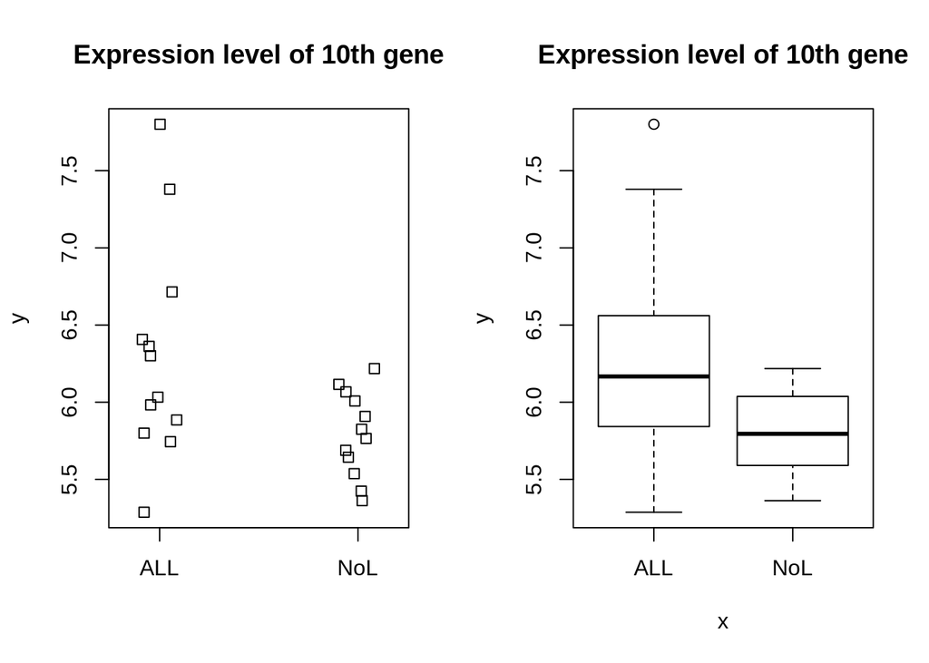

```r
par(mfrow=c(1,2))
stripchart(y~x,vertical=T,method="jitter",main="Expression level of 10th gene")
boxplot(y~x,main="Expression level of 10th gene")
```

Difference? yes. Significant difference? Well this needs further examination.

We can fit a linear model using `lm()`. The first step is to create a model matrix.

```r
X  <- model.matrix(~x)
head(X)
```

```
##   (Intercept) xNoL
## 1           1    0
## 2           1    0
## 3           1    0
## 4           1    0
## 5           1    0
## 6           1    0
```

```r
# rename X
colnames(X)[2] <-"NoL"
head(X)
```

```
##   (Intercept) NoL
## 1           1   0
## 2           1   0
## 3           1   0
## 4           1   0
## 5           1   0
## 6           1   0
```

```r
fit <- lm(y~X+0) # +0 means not add a new intercept when lm() is called
summary(fit)
```

```
##
## Call:
## lm(formula = y ~ X + 0)
##
## Residuals:
##      Min       1Q   Median       3Q      Max
## -1.02082 -0.33735 -0.01944  0.22582  1.49288
##
## Coefficients:
##              Estimate Std. Error t value Pr(>|t|)
## X(Intercept)   6.3080     0.1554  40.592   <2e-16 ***
## XNoL          -0.5111     0.2198  -2.326   0.0296 *
## ---
## Signif. codes:  0 '***' 0.001 '**' 0.01 '*' 0.05 '.' 0.1 ' ' 1
##
## Residual standard error: 0.5383 on 22 degrees of freedom
## Multiple R-squared:  0.9928, Adjusted R-squared:  0.9922
## F-statistic:  1520 on 2 and 22 DF,  p-value: < 2.2e-16
```

Since `Pr(>|t|)` for second coefficient `XNoL` is 0.0296 and smaller than 0.05, we can conclude that there is significant difference in expression level of 10th gene between ALL patients and healthy people.

## Solve linear regression using matrix inverse

For linear model construction, we assume that the true relationship between `X` and `y` is $y=X\beta+\epsilon$. Since `lm()` uses least square estimation, it tries to find $\hat\beta$ such that the residual sum of squares $RSS=(Y-X\beta)^T(Y-X\beta)$ is minimized. By solving $\frac{\partial RSS}{\partial \beta}=0$ we have $X^TX\hat\beta=X^TY$. The solution is
$$\hat\beta=(X^T X)^{-1}X^T Y$$
Let’s see whether this method produce same result as `lm()`.

```r
solve(t(X) %*% X) %*% t(X) %*% y
```

```
##                   [,1]
## (Intercept)  6.3080373
## NoL         -0.5111393
```

Hooray! Same result!! Even simpler code:

```r
solve(crossprod(X)) %*% crossprod(X,y)
```

```
##                   [,1]
## (Intercept)  6.3080373
## NoL         -0.5111393
```

## Solve linear regression using QR factorization

If we can factorize $X$ into the product of an orthomornal matrix $Q$ ($Q^T Q=I$) and an upper triangular matrix $R$, then $X^TX\hat\beta=X^TY$ can be simplified:
$$(QR)^T(QR)\beta=(QR)^T Y$$
$$R^T R\beta=R^T Q^T Y$$
$$R\beta=Q^T Y$$
Function `qr()` can perform QR decomposition:

```r
QR <- qr(X)
QR
```

```
## $qr
##    (Intercept)        NoL
## 1   -4.8989795 -2.4494897
## 2    0.2041241  2.4494897
## 3    0.2041241  0.1695208
## 4    0.2041241  0.1695208
## 5    0.2041241  0.1695208
## 6    0.2041241  0.1695208
## 7    0.2041241  0.1695208
## 8    0.2041241  0.1695208
## 9    0.2041241  0.1695208
## 10   0.2041241  0.1695208
## 11   0.2041241  0.1695208
## 12   0.2041241  0.1695208
## 13   0.2041241 -0.2387274
## 14   0.2041241 -0.2387274
## 15   0.2041241 -0.2387274
## 16   0.2041241 -0.2387274
## 17   0.2041241 -0.2387274
## 18   0.2041241 -0.2387274
## 19   0.2041241 -0.2387274
## 20   0.2041241 -0.2387274
## 21   0.2041241 -0.2387274
## 22   0.2041241 -0.2387274
## 23   0.2041241 -0.2387274
## 24   0.2041241 -0.2387274
## attr(,"assign")
## [1] 0 1
## attr(,"contrasts")
## attr(,"contrasts")$x
## [1] "contr.treatment"
##
##
## $rank
## [1] 2
##
## $qraux
## [1] 1.204124 1.169521
##
## $pivot
## [1] 1 2
##
## attr(,"class")
## [1] "qr"
```

```r
Q <- qr.Q(QR)
Q
```

```
##             [,1]       [,2]
##  [1,] -0.2041241 -0.2041241
##  [2,] -0.2041241 -0.2041241
##  [3,] -0.2041241 -0.2041241
##  [4,] -0.2041241 -0.2041241
##  [5,] -0.2041241 -0.2041241
##  [6,] -0.2041241 -0.2041241
##  [7,] -0.2041241 -0.2041241
##  [8,] -0.2041241 -0.2041241
##  [9,] -0.2041241 -0.2041241
## [10,] -0.2041241 -0.2041241
## [11,] -0.2041241 -0.2041241
## [12,] -0.2041241 -0.2041241
## [13,] -0.2041241  0.2041241
## [14,] -0.2041241  0.2041241
## [15,] -0.2041241  0.2041241
## [16,] -0.2041241  0.2041241
## [17,] -0.2041241  0.2041241
## [18,] -0.2041241  0.2041241
## [19,] -0.2041241  0.2041241
## [20,] -0.2041241  0.2041241
## [21,] -0.2041241  0.2041241
## [22,] -0.2041241  0.2041241
## [23,] -0.2041241  0.2041241
## [24,] -0.2041241  0.2041241
```

```r
R <- qr.R(QR)
R
```

```
##   (Intercept)      NoL
## 1   -4.898979 -2.44949
## 2    0.000000  2.44949
```

```r
backsolve(R, crossprod(Q,y) )
```

```
##            [,1]
## [1,]  6.3080373
## [2,] -0.5111393
```